# 2016 Snohomish Focus Study - PCA analysis

```r
library(tidyverse)
```

PCAs work best with numerical data, so exclude categorical data

```r
summary(SnoDat.pca)
```

```
Importance of components:
                          PC1    PC2    PC3
Standard deviation     1.2818 0.9772 0.6341
Proportion of Variance 0.5476 0.3183 0.1340
Cumulative Proportion  0.5476 0.8660 1.0000
```

PC1 and PC2 combine explain 87% of the variance combine

```r
str(SnoDat.pca)
```

```
List of 5
 $ sdev    : num [1:3] 1.282 0.977 0.634
 $ rotation: num [1:3, 1:3] -0.683 -0.684 -0.256 0.189 0.173 ...
  ..- attr(*, "dimnames")=List of 2
  .. ..$ : chr [1:3] "TotalPCBs" "SumBDE" "SumDDTs"
  .. ..$ : chr [1:3] "PC1" "PC2" "PC3"
 $ center  : Named num [1:3] 20.47 8.85 2.41
  ..- attr(*, "names")= chr [1:3] "TotalPCBs" "SumBDE" "SumDDTs"
 $ scale   : Named num [1:3] 13 10.9 1.2
  ..- attr(*, "names")= chr [1:3] "TotalPCBs" "SumBDE" "SumDDTs"
 $ x       : num [1:48, 1:3] 0.309 0.65 0.309 -0.219 -3.192 ...
  ..- attr(*, "dimnames")=List of 2
  .. ..$ : NULL
  .. ..$ : chr [1:3] "PC1" "PC2" "PC3"
 - attr(*, "class")= chr "prcomp"
```

$center = center point $scale = scale sdev = standard deviation of each principal component $rotation = the relationship (correlation or anticorrelation, etc.) between the initial variables and the principal components $x = the values of each sample in terms of the principal components

PLOTTING THE PCA

The biplot allows you to visualize how the samples relate to one another in the PCA (which samples are similar and which are different) and will simultaneously reveal how each variable contributes to each principal component.

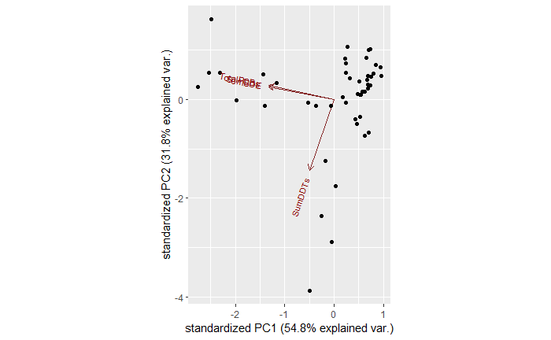

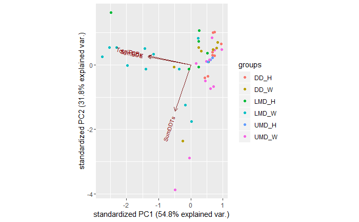

Group by Region and Origin

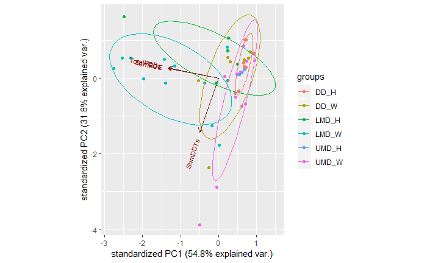

Scale the samples

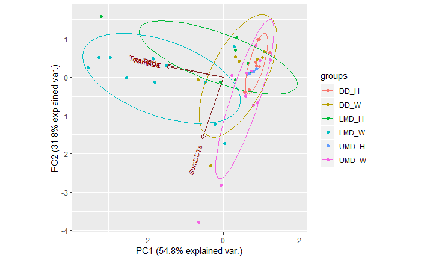

Remove the arrows

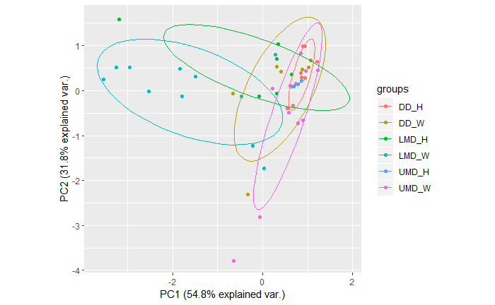

Use the ggplot functions to customize the ggbiplot

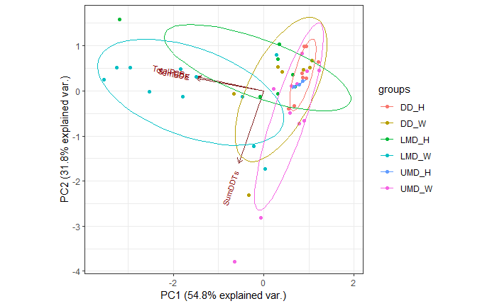